# **Modelación del movimiento en ingeniería**

# Álgebra de vectores

### M. en C. Jonathan A. Urrutia Anguiano

### F1006B.218

## ¿Qué es un vector?

Formalmente, un vector $\vec{v}$ es un elemento de un espacio vectorial $\mathcal{V}$ el cual se define por:

- Una estructura algebráica $\mathcal{C}$ conocida como campo
  - $\lambda \in \mathcal{C}$ son conocidos como escalares
- Una operación $(+)$ llamada *suma* entre dos vecores $u$ y $v$
- Una operación $(\cdot)$ llamada *multiplicación por escalar* entre un escalar $\lambda$ y un vector $\vec{v}$
- Las operaciones anteriores deben cumplir con una lista de [ocho propiedades](https://es.wikipedia.org/wiki/Espacio_vectorial#Definici%C3%B3n)

Adicionalmente es posible definir operaciones entre elementos de vectores además de la suma:

- Producto punto
- Producto cruz

## Ejemplos de espacios vectoriales

### Vectores en dos dimensiones

- $\mathcal{V} = \mathbb{R}^2$, con $\mathcal{C} = \mathbb{R}$
  - $\vec{v} = (v_x, v_y) \in \mathbb{R}^2 , \qquad\lambda \in \mathbb{R}$
  - $(+)$: $\vec{v}+\vec{u} = (v_x, v_y) + (u_x, u_y) = (v_x + u_x, v_y + u_y)$
  - $(\cdot)$: $\lambda\vec{v} = \lambda (v_x, v_y) = (\lambda v_x, \lambda v_x)$

Se define la **base canónica** del espacio vectorial $\mathbb{R}^2$ como

- $\hat{e}_x = \hat{x} = \hat{i} = (1,0)$
- $\hat{e}_y = \hat{y} = \hat{j} = (0,1)$

Esto permite escribir cualquier elemento $\vec{v}\in \mathbb{R}^2$ como una combinación lineal de la base canónica: $$\vec{v} = v_x \hat{e}_x + v_y \hat{e}_y,\qquad\text{con}\qquad v_x,v_y \in \mathbb{R}.$$

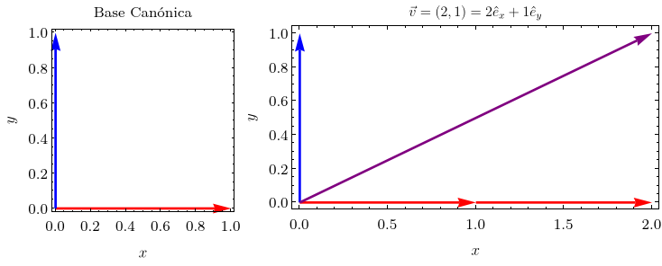

### Vectores en tres dimensiones

- $\mathcal{V} = \mathbb{R}^3$, con $\mathcal{C} = \mathbb{R}$
  - $\vec{v} = (v_x, v_y, v_z) \in \mathbb{R}^3 , \qquad\lambda \in \mathbb{R}$
  - $(+)$: $\vec{v}+\vec{u} = (v_x, v_y, v_z) + (u_x, u_y, u_z) = (v_x + u_x , v_y + u_y, v_z + u_z)$
  - $(\cdot)$: $\lambda\vec{v} = \lambda (v_x, v_y, v_z) = (\lambda v_x, \lambda v_y, \lambda u_z)$

Se define la **base canónica** del espacio vectorial $\mathbb{R}^3$ como

- $\hat{e}_x = \hat{x} = \hat{i} = (1,0,0)$
- $\hat{e}_y = \hat{y} = \hat{j} = (0,1,0)$
- $\hat{e}_z = \hat{z} = \hat{k} = (0,0,1)$

Esto permite escribir cualquier elemento $\vec{v}\in \mathbb{R}^3$ como una combinación lineal de la base canónica: $$\vec{v} = v_x \hat{e}_x + v_y \hat{e}_y + v_z \hat{e}_z,\qquad\text{con}\qquad v_x,v_y, v_z \in \mathbb{R}.$$

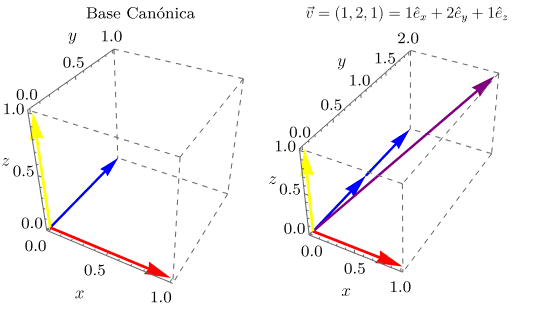

## Multiplicación por escalar

Todos los espacios vectoriales de la forma $\mathbb{R}^n$, es decir $n$-adas ordenadas, se comportan de forma semejante bajo la suma y el producto por escalar.

Por lo mismo ejempleficaremos este comportamiento con $\mathbb{R}^2$, considerando los siguientes casos para escalares $\lambda$:

Ejemplos de cantidades físicas:

- Fuerza $\vec{F}$ ejercida por una carga $q$ debido a un campo eléctrico $\vec{E}$: $\qquad\vec{F} = q \vec{E}$.
- Momento lineal $\vec{p}$ de una partícula de masa $m$ y velocidad $\vec{v}$: $\qquad\vec{p} = m \vec{v}$.

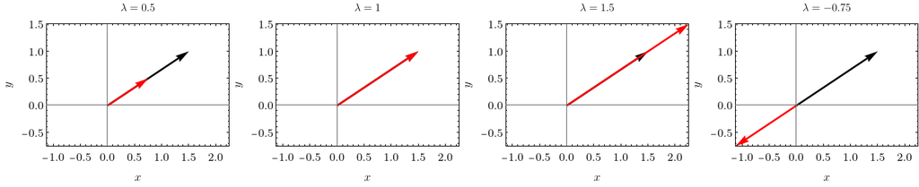

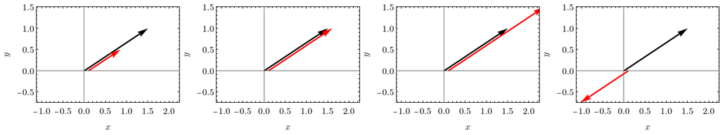

## Producto punto

### Procedimiento por componentes

También conocido como **producto escalar**, ésta es una oeración entre dos elemenos $v$ y $w$ de un espacio vectorial que tiene como resultado un valor escalar. Para el caso de vectores en $\mathbb{R}^2$ y $\mathbb{R}^3$, el producto punto se define como:

$$ \begin{aligned} \vec{v}\cdot \vec{w} &= (v_x,v_y) \cdot (w_x,w_y) = v_x w_x + v_y w_y\\ \\ \vec{v}\cdot \vec{w} &= (v_x,v_y,v_z) \cdot (w_x,w_y,w_z) = v_x w_x + v_y w_y + v_z w_z \end{aligned} $$

A partir de la definición, podemos ver que el producto punto es una operación conmitativa, es decir,

$$\vec{v} \cdot \vec{w} = \vec{w} \cdot\vec{v}$$

### Calculando la norma de un vector

Podemos ver que al calcular el producto punto a un vector consigo mismo, se obtiene una expresión conocida como (el cuadraro de) la norma euclidiana

$$ \begin{aligned} \vec{v}\cdot \vec{v} &= (v_x,v_y) \cdot (v_x,v_y) = v_x ^2+ v_y ^2 = ||\vec{v} ||^2\\ \\ \vec{w}\cdot \vec{w} &= (w_x,w_y,w_z) \cdot (w_x,w_y,w_z) = w_x^2 + w_y^2 + w_z ^2 = ||\vec{w}||^2 \end{aligned} $$

La norma define la distancia o magnitud del vector, que es una intepretación geométrica del producto punto.

¿Cómo se interpreta el producto punto si se realiza con dos vectores distintos?

### Interpretación geométrica

Una interpretación geométrica del producto punto surge a partir de considerar un triángulo con dos vectores $\vec{u}$, $\vec{v}$ y el vector que une sus dos extremos: $(\vec{u}-\vec{v}$).

[output not shown]

En la expresión anterior, $\theta$ es el ángulo entre los vectores $u$ y $v$, por lo que al modular una de las normas de estos vectores con el $\cos\theta$ lo que se obtiene es qué parte de un vector se empalma sobre el otro.

Imagen: [Math buff](https://commons.wikimedia.org/wiki/File:Dot_product_cosine_law.svg), [CC BY-SA 4.0](https://creativecommons.org/licenses/by-sa/4.0), via Wikimedia Commons

### Interpretación geométrica

Una interpretación geométrica del producto punto surge a partir de considerar un triángulo con dos vectores $\vec{u}$, $\vec{v}$ y el vector que une sus dos extremos: $(\vec{u}-\vec{v}$).

[output not shown]

En la expresión anterior, $\theta$ es el ángulo entre los vectores $u$ y $v$, por lo que al modular una de las normas de estos vectores con el $\cos\theta$ lo que se obtiene es qué parte de un vector se empalma sobre el otro.

Imagen: [Math buff](https://commons.wikimedia.org/wiki/File:Dot_product_cosine_law.svg), [CC BY-SA 4.0](https://creativecommons.org/licenses/by-sa/4.0), via Wikimedia Commons

### Vectores paralelos y ortogonales

Dado que $\vec{v}\cdot \vec{v} = ||\vec{u}|| ||\vec{v}|| \cos\theta$, podemos definir que un vector es paralelo o perpendicular a otro, sí:

- **Perpendicular**: $\vec{v}\cdot \vec{v} = 0$, pues $\theta = \pi/2$, es decir $\cos(\theta) = 0$
- **Paralelo**: $\vec{v}\cdot \vec{v} = ||\vec{u}|| ||\vec{v}|| $, pues $\theta = 0$, es decir $\cos(\theta) = 1$
- **Antiparalelo**: $\vec{v}\cdot \vec{v} = -||\vec{u}|| ||\vec{v}|| $, pues $\theta = \pi$, es decir $\cos(\theta) = -1$

### Vectores unitarios

Algunas veces es de utilidad trabajar con vectores cuya norma sea igual a la unidad. A estos vectores se les conoce como **vectores unitarios** y se denotan con una cuña en lugar de una flecha sobre el símbolo que representa a cada vector. Algunos ejemplos son los elementos de la base canónica cartesiana $\hat{e}_x,\,\hat{e}_y$ y $\hat{e}_z$, o bien vectores como $\hat{a} = (1,1)/\sqrt{2}$.

Es posible construir un vector unitario a partir de cualquier otro al dividir el vector entre su norma:

$$ \hat{b} = \frac{\vec{b} }{||\vec{b}||} = \frac{\vec{b}}{\sqrt{\vec{b}\cdot\vec{b}}}, \qquad ||\hat{b}|| = 1 $$

### Proyecciones

|  | $$ \begin{aligned} \text{proy}_{\vec{u}}(\vec{v}) =& \|\|\vec{u}\|\|\cos\theta\\ =& \vec{u}\cdot\hat{v}\\ =& \vec{u}\cdot\left(\frac{\vec{v}}{\|\|\vec{v}\|\|}\right) \end{aligned} $$ | $$ \begin{aligned} \text{proy}_{\vec{v}}(\vec{u}) =& \|\|\vec{v}\|\|\cos\theta\\ =& \vec{v}\cdot\hat{u}\\ =& \vec{v}\cdot\left(\frac{\vec{u}}{\|\|\vec{u}\|\|}\right) \end{aligned} $$ |
| --- | --- | --- |

### Componentes de un vector

Suponiendo que queremos operar con el vector $\vec{v}$, con las operaciones que hemos presentado sólo es posible si lo conocesmos en su representación $\vec{v} = (v_x, v_y) = v_x \hat{e}_x + v_y \hat{e}_y$, es decir, si conocemos sus componentes.

- ¿Qué sucede su nos proporcionan la magnitud y la dirección del vector y no sus componentes?

[output not shown]

Imagen: [User:Acdx](https://commons.wikimedia.org/wiki/File:3D_Vector.svg), [CC BY-SA 4.0](https://creativecommons.org/licenses/by-sa/4.0), via Wikimedia Commons

## Producto cruz

También conocido como **producto vectorial**, ésta es una operación entre dos elemenos $a$ y $b$ del espacio vectorial $\mathbb{R}^3$ que tiene como resultado un tercer vector. Esta operación se denota como

$$ \vec{c} = \vec{a}\times \vec{b} $$

y tiene las siguientes caracterísiticas:

- $\vec{c} \cdot \vec{a} = \vec{c} \cdot \vec{b} = 0$
- $\vec{b}\times\vec{a} = - (\vec{a}\times\vec{b})$

Es decir, el producto cruz entre $\vec{a}$ y $\vec{b}$ da como resultado un vector perpendicular a ellos dos, además de que el producto cruz es antisimétrico.

Ejemplos de cantidades física:

- Fuerza $\vec{F}$ debido a una carga $q$ con velocidad $q$ en un campo magnético $\vec{B}$: $\qquad \vec{F} = q \vec{v} \times \vec{B}$
- Momento angular $\vec{L}$ de una partícula con momento lineal $\vec{p}$ a una distancia $\vec{r}$ del origen: $\qquad \vec{L} = \vec{r} \times \vec{p}$

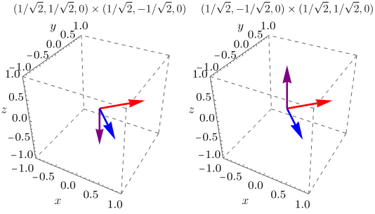

### Cálculo del producto cruz: Por componentes

Si escribimos $\vec{a} = (a_x,a_y,a_z)$ y $\vec{b} = (b_x,b_y,b_z)$, el producto cruz se calcula como

$$ \vec{a}\times \vec{b} = (a_y b_z - a_z b_y,\; a_z b_x - a_x b_z,\; a_x b_y - a_y b_x ) $$

Mediante un abuso de notación, podemos calcular el producto cruz como

$$ \vec{a}\times \vec{b} = \det\left( \begin{array}{ccc} \hat{e}_x & \hat{e}_y & \hat{e}_z \\ a_x & a_y & a_z \\ b_x & b_y & b_z \end{array}\right) = \hat{e}_x \det\left( \begin{array}{cc} a_y & a_z \\ b_y & b_z \end{array}\right) -\hat{e}_y \det\left( \begin{array}{cc} a_x & a_z \\ b_x & b_z \end{array}\right) + \hat{e}_z\det\left( \begin{array}{cc} a_x & a_y\\ b_x & b_y \end{array}\right) $$

### Cálculo del producto cruz: Regla de la mano derecha

Finalmente, es [posible probar](https://www.khanacademy.org/math/linear-algebra/vectors-and-spaces/dot-cross-products/v/proof-relationship-between-cross-product-and-sin-of-angle) que la magnitud del proudcto cruz entre dos vectores cumple con:

|  | $$ \|\| \vec{a}\times \vec{b} \|\| = \|\|\vec{a}\|\| \|\|\vec{b}\|\| \sin\theta $$ |  |
| --- | --- | --- |

[User:Acdx](https://commons.wikimedia.org/wiki/File:Cross_product_parallelogram.svg), Public domain, via Wikimedia Commons

[Acdx](https://commons.wikimedia.org/wiki/File:Right_hand_rule_cross_product.svg), [CC BY-SA 3.0](http://creativecommons.org/licenses/by-sa/3.0/), via Wikimedia Commons

## Ejercicio en clase:

Sea $\vec{A} = (3,4,-1)$ y $\vec{B} = (2,7,1)$. Calcular:

- $\vec{A}+\vec{B}$
- $\vec{A}-\vec{B}$
- $||\vec{A}||$
- $||\vec{B}||$
- El coseno del ángulo entre $\vec{A}$ y $\vec{B}$
- El seno del ángulo entre $\vec{A}$ y $\vec{B}$